# Single Patient Prediction

# Introduction

This notebook provides a running example of estimating the following values, for a single patient:

- probability of death
- probability of future visit to critical state
- quantiles of predicted time in hospital
- quantiles of predicted time in critical state
- Cumulative Distribution Function (CDF) for remaining time at hospital

**Note:** In the code, the constants denoting the states are named `MILD`, `MODERATE` and `SEVERE`. In the paper these constants correspond with the states named Moderate, Severe and Critical, respectively.

# Follow These Steps:

## 1. Define Patient Covariates:

We shall provide estimates for a 55 year old male hospitalized in a critical condition. Predictions below are done from time of hospitalization but estimates can be predicted from any time since hospitalization.

### Sex

Either `MALE` of `FEMALE`

```r
sex = MALE
```

### Age (in years)

```r
age = 55
```

### Patient’s State at Hospitalization

Denoted as `entry_state`, this can be either MILD, MODERATE or SEVERE.

NOTE: in the paper, these are named MODERATE, SEVERE and CRITICAL respectively.

```r
entry_state = SEVERE
```

### Patient’s Current State

For prediction from time of hospitalization this is necessarily the same as entry_state, but if we predict from some time during hospitalization this can be another state.

```r
current_state = SEVERE
```

### Days since hospitalization until entry to current state

Integer number of days since hospitalization until the patient entered the current state

Examples:

1. For prediction from day of hospitalization (necessarily from first state) use: 0
2. If the patient was hospitalized for 10 days, 3 of them spent in the current state, then 7 days have passed since hospitalization until entry to the curent state, use: 7

```r
days_since_hospitalization_until_entry_to_current_state = 0
```

### Days spent at current state

Integer number of days spent at the current state

Examples:

1. For prediction from day of hospitalization (necessarily from first state) use: 0
2. If patient was hospitalized for 10 days, and is already 3 days in the current state, use: 3

```r
days_at_current_state = 0
```

From the two definitions above we have:

```r
total_days_since_hospitalization = days_since_hospitalization_until_entry_to_current_state +
                                   days_at_current_state
```

### Indicator Variable for Previous Visit to `SEVERE` State:

A binary 0/1 indicator of a **past** visit to the `SEVERE` state (In the paper: “Critical”). 1 indicates there was such a visit.

Note: if the patient was hospitalized in `SEVERE` state, the indicator should initially be 0, as there was no **past** visit to the `SEVERE` state.

```r
was_severe = 0
```

### Construct The Covariates:

```r
covariates = construct_covariates(sex = sex,
                                  age = age,
                                  entry_state = entry_state,
                                  cumulative_time = days_since_hospitalization_until_entry_to_current_state,
                                  was_severe = was_severe)
```

## 2. Decide if you wish to compute confidence intervals

This notebook computes 95% confidence intervals for the estimates listed above. Intervals are estimated using a weighted bootstrap based on 100 models, i.e 100 models each running 20K monte carlo simulations. This can be relatively slow.

Note: For estimates of the different quantiles of hospitalization time remaining and time remaining in a critical state, in estimates of extreme quantiles, coverage could possibly differ from 95%.

```r
COMPUTE_CONFIDENCE_INTERVALS = TRUE
```

## 3. Set Monte Carlo Paramaters:

### Define the number of monte carlo paths to sample:

```r
M_MONTE_CARLO_PATHS = 20*1000 # recommended
```

### Set maximum state transitions

This is used to exclude outlier paths. For instance, this rule can be used to exclude occurences of paths longer than those observed in the data.

```r
MAX_TRANSITIONS = 9 # recommended
```

## 4. Predict:

```r
monte_carlo_runs = israeli_model$run_monte_carlo_simulation(covariates,
                                                            to_model_state(current_state), # model uses a merged moderate/mild state
                                                            current_time = total_days_since_hospitalization,
                                                            n_random_samples = M_MONTE_CARLO_PATHS,
                                                            max_transitions = MAX_TRANSITIONS)

estimates =  data.frame(estimate = t(compute_statistics(monte_carlo_runs)))

if (COMPUTE_CONFIDENCE_INTERVALS) {
  bootstrap_sd = compute_sd_using_bootstrap(bootstrap_models,
                                            covariates,
                                            current_state,
                                            total_days_since_hospitalization,
                                            M_MONTE_CARLO_PATHS,
                                            MAX_TRANSITIONS)

  estimates["Standard Deviation"] = as.numeric(bootstrap_sd)
  estimates["95%-lower"] = estimates$estimate - 1.96*as.numeric(bootstrap_sd)
  estimates["95%-upper"] = estimates$estimate + 1.96*as.numeric(bootstrap_sd)
}
```

### Predicted Estimates:

```r
formattable(estimates)
```

|  | estimate | Standard Deviation | 95%-lower | 95%-upper |
| --- | --- | --- | --- | --- |
| probability_of_death | 0.135700 | 0.00541273 | 0.125091 | 0.146309 |
| probability_of_visit_to_severe_state | 1.000000 | 0.00000000 | 1.000000 | 1.000000 |
| time_hospitalized_remaining_quantile_0.1 | 8.000045 | 0.23866984 | 7.532252 | 8.467838 |
| time_hospitalized_remaining_quantile_0.25 | 16.000021 | 0.43239706 | 15.152523 | 16.847519 |
| time_hospitalized_remaining_quantile_0.5 | 28.000062 | 0.85244195 | 26.329276 | 29.670849 |
| time_hospitalized_remaining_quantile_0.75 | 44.000064 | 0.90431368 | 42.227609 | 45.772518 |
| time_hospitalized_remaining_quantile_0.9 | 47.000093 | 0.20000209 | 46.608089 | 47.392097 |
| time_remaining_in_severe_state_quantile_0.1 | 4.000041 | 0.49680951 | 3.026295 | 4.973788 |
| time_remaining_in_severe_state_quantile_0.25 | 8.000099 | 0.32951883 | 7.354242 | 8.645956 |
| time_remaining_in_severe_state_quantile_0.5 | 17.000087 | 0.44945990 | 16.119146 | 17.881028 |
| time_remaining_in_severe_state_quantile_0.75 | 29.000006 | 0.95190552 | 27.134271 | 30.865741 |
| time_remaining_in_severe_state_quantile_0.9 | 42.000019 | 0.90000228 | 40.236014 | 43.764023 |

### CDF of remaining time in hospital:

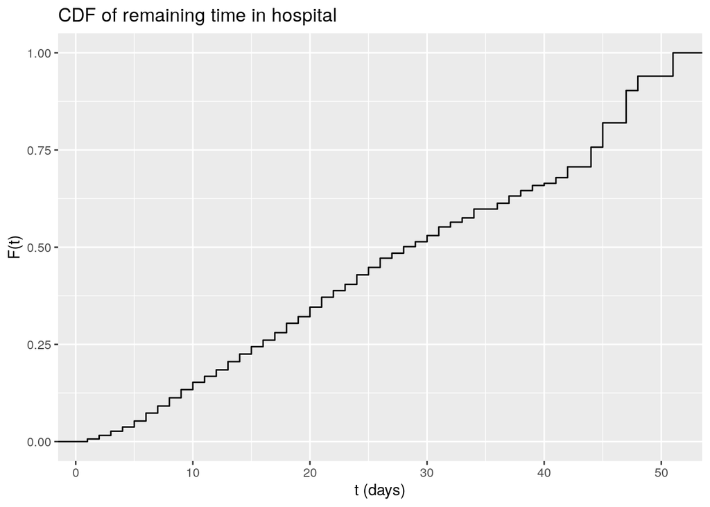

```r
plot_cdf_of_remaining_time_in_hospital(monte_carlo_runs)
```